# Instrumental Variables from Scratch

Quantitative Economics

Swapnil Singh

# Learning goals

1. See **why OLS fails** under simultaneity — with algebra and simulation
2. Build the **IV / TSLS estimator from scratch** (no packages)
3. Apply IV to **real data**: returns to education using Card (1995)
4. Compare our hand-coded estimates to `ivreg`

# Part 1: Simulation — supply and demand

We replicate the simultaneity example from the lecture slides.

## The data-generating process

$$\text{Demand}: \quad Q_i = \alpha_0 + \alpha_1 P_i + u_i^d \qquad
(\alpha_1 < 0)$$
$$\text{Supply}: \quad Q_i = \gamma_0 + \gamma_1 P_i + \delta Z_i + u_i^s
\qquad (\gamma_1 > 0)$$

- $Z_i$ is a **supply shifter** (e.g., weather, input costs) — it enters supply but *not* demand.
- Equilibrium: set demand $=$ supply, solve for $P_i$ and $Q_i$.

```r
# True parameters
alpha0 <- 10     # demand intercept
alpha1 <- -0.5   # demand slope (negative: law of demand)
gamma0 <- 2      # supply intercept
gamma1 <- 0.8    # supply slope (positive: upward-sloping supply)
delta  <- 1.5    # effect of supply shifter Z on quantity supplied

n <- 5000        # sample size
```

## Solving for equilibrium

Setting demand equal to supply and solving:

$$P_i = \frac{(\gamma_0 - \alpha_0) + \delta Z_i + (u_i^s -
u_i^d)}{\alpha_1 - \gamma_1}$$

Then plug back into demand to get $Q_i$.

```r
# Exogenous shocks
Z   <- rnorm(n, mean = 5, sd = 2)   # supply shifter (e.g., rainfall index)
u_d <- rnorm(n, mean = 0, sd = 1)   # demand shock
u_s <- rnorm(n, mean = 0, sd = 1)   # supply shock (independent of u_d)

# Equilibrium price (from setting demand = supply)
P <- ((gamma0 - alpha0) + delta * Z + (u_s - u_d)) / (alpha1 - gamma1)

# Equilibrium quantity (plug P into demand equation)
Q <- alpha0 + alpha1 * P + u_d

sim <- data.frame(P = P, Q = Q, Z = Z, u_d = u_d, u_s = u_s)
```

## Why is $P$ endogenous?

The equilibrium price depends on the demand shock $u^d$. Let’s verify:

```r
cat("cov(P, u_d) =", cov(P, u_d), "\n")
```

```
## cov(P, u_d) = 0.7689
```

```r
cat("cor(P, u_d) =", cor(P, u_d), "\n")
```

```
## cor(P, u_d) = 0.2993
```

The covariance is clearly nonzero — $P$ is **endogenous** in the demand equation.

Meanwhile, our instrument $Z$ is exogenous (uncorrelated with $u^d$) but relevant (correlated with $P$):

```r
cat("Exogeneity:  cov(Z, u_d) =", cov(Z, u_d), "\n")
```

```
## Exogeneity:  cov(Z, u_d) = -0.004936
```

```r
cat("Relevance:   cov(Z, P)   =", cov(Z, P),   "\n")
```

```
## Relevance:   cov(Z, P)   = -4.642
```

## OLS: biased and inconsistent

```r
ols_fit <- lm(Q ~ P, data = sim)
cat("True demand slope (alpha1):", alpha1, "\n")
```

```
## True demand slope (alpha1): -0.5
```

```r
cat("OLS estimate:              ", coef(ols_fit)["P"], "\n")
```

```
## OLS estimate:               -0.3817
```

OLS is badly biased. From the lecture, we know:

```r
sigma_d2 <- var(u_d)
sigma_s2 <- var(u_s)
plim_ols <- (alpha1 * sigma_s2 + gamma1 * sigma_d2) / (sigma_s2 + sigma_d2)
cat("Theoretical plim of OLS:   ", plim_ols, "\n")
```

```
## Theoretical plim of OLS:    0.1533
```

```r
cat("OLS estimate:              ", coef(ols_fit)["P"], "\n")
```

```
## OLS estimate:               -0.3817
```

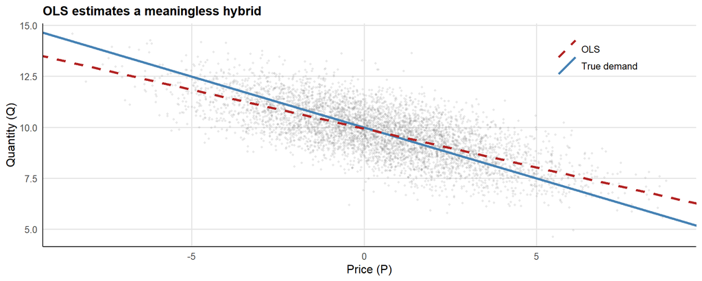

```r
ggplot(sim, aes(x = P, y = Q)) +
  geom_point(alpha = 0.15, size = 0.8, colour = "grey50") +
  geom_abline(aes(intercept = alpha0, slope = alpha1, colour = "True demand"),
              linewidth = 1.2) +
  geom_abline(aes(intercept = coef(ols_fit)[1], slope = coef(ols_fit)[2],
                  colour = "OLS"),
              linewidth = 1.2, linetype = "dashed") +
  scale_colour_manual(values = c("True demand" = "steelblue",
                                  "OLS" = "firebrick")) +
  labs(title = "OLS estimates a meaningless hybrid",
       x = "Price (P)", y = "Quantity (Q)", colour = NULL) +
  theme(legend.position = c(0.85, 0.85))
```

# Part 2: IV / TSLS from scratch

We now implement the two-stage least squares estimator **by hand**, following the derivation from the lecture.

## The TSLS recipe

1. **First stage**: Regress $X$ on $Z$ to get fitted values $\widehat{X}$
2. **Second stage**: Regress $Y$ on $\widehat{X}$

Or equivalently (as we derived): $\hat{\beta}_1^{TSLS} = s_{ZY} / s_{ZX}$.

## Implementation: Wald / ratio estimator

```r
# TSLS as ratio of sample covariances (Wald estimator)
iv_ratio <- cov(Z, Q) / cov(Z, P)

cat("True demand slope (alpha1):", alpha1, "\n")
```

```
## True demand slope (alpha1): -0.5
```

```r
cat("IV estimate (Wald ratio):  ", iv_ratio, "\n")
```

```
## IV estimate (Wald ratio):   -0.4989
```

```r
cat("OLS estimate:              ", coef(ols_fit)["P"], "\n")
```

```
## OLS estimate:               -0.3817
```

IV recovers the true parameter. Let’s also do it via the two-stage procedure.

## Implementation: two-stage procedure

```r
# ---- Stage 1: regress P on Z ----
stage1 <- lm(P ~ Z, data = sim)
P_hat  <- fitted(stage1)

cat("First-stage coefficient (pi_1):", coef(stage1)["Z"], "\n")
```

```
## First-stage coefficient (pi_1): -1.149
```

```r
cat("First-stage F-statistic:       ", summary(stage1)$fstatistic[1], "\n\n")
```

```
## First-stage F-statistic:        22822
```

```r
# ---- Stage 2: regress Q on P_hat ----
stage2 <- lm(Q ~ P_hat)

cat("True demand slope (alpha1):    ", alpha1, "\n")
```

```
## True demand slope (alpha1):     -0.5
```

```r
cat("TSLS estimate (two-stage):     ", coef(stage2)["P_hat"], "\n")
```

```
## TSLS estimate (two-stage):      -0.4989
```

```r
cat("IV estimate (Wald ratio):      ", iv_ratio, "\n")
```

```
## IV estimate (Wald ratio):       -0.4989
```

Both routes give the same answer.

### Verify the algebra: why they are identical

From the lecture derivation:

$$\hat{\beta}_1^{TSLS} = \frac{s_{\widehat{X}Y}}{s_{\widehat{X}}^2}
= \frac{\hat{\pi}_1 \, s_{ZY}}{\hat{\pi}_1^2 \, s_Z^2}
= \frac{s_{ZY}}{\hat{\pi}_1 \, s_Z^2}
= \frac{s_{ZY}}{s_{ZX}}$$

```r
pi1_hat <- cov(Z, P) / var(Z)          # first-stage slope

# Numerator path
s_XhatY <- cov(P_hat, Q)
cat("s_{X̂,Y}      =", s_XhatY, "\n")
```

```
## s_{X̂,Y}      = -2.661
```

```r
cat("π̂₁ × s_{ZY}  =", pi1_hat * cov(Z, Q), "\n\n")
```

```
## π̂₁ × s_{ZY}  = -2.661
```

```r
# Denominator path
s_Xhat2 <- var(P_hat)
cat("s²_{X̂}       =", s_Xhat2, "\n")
```

```
## s²_{X̂}       = 5.333
```

```r
cat("π̂₁² × s²_Z   =", pi1_hat^2 * var(Z), "\n\n")
```

```
## π̂₁² × s²_Z   = 5.333
```

```r
# Final ratio
cat("s_{X̂,Y}/s²_{X̂}  =", s_XhatY / s_Xhat2, "\n")
```

```
## s_{X̂,Y}/s²_{X̂}  = -0.4989
```

```r
cat("s_{ZY}/s_{ZX}     =", cov(Z, Q) / cov(Z, P), "\n")
```

```
## s_{ZY}/s_{ZX}     = -0.4989
```

## Building a reusable IV function

```r
iv_estimate <- function(y, x, z) {
  # ---------------------------------------------------------------
  # Hand-coded TSLS for simple IV (one endogenous regressor, one instrument)
  #
  # Args:
  #   y : outcome vector
  #   x : endogenous regressor vector
  #   z : instrument vector (or matrix for multiple instruments)
  #
  # Returns: list with coefficients, standard errors, first-stage F

  # ---------------------------------------------------------------
  n <- length(y)

  # --- First stage: x on z (with intercept) ---
  Z_mat <- cbind(1, z)
  pi_hat <- solve(crossprod(Z_mat), crossprod(Z_mat, x))   # OLS coefficients
  x_hat  <- Z_mat %*% pi_hat                                # fitted values
  e1     <- x - x_hat                                       # first-stage residuals

  # First-stage F-statistic (for single instrument: t² = F)
  pi_se  <- sqrt(sum(e1^2) / (n - ncol(Z_mat)) / sum((z - mean(z))^2))
  F_stat <- (pi_hat[2] / pi_se)^2

  # --- Second stage: y on x_hat (with intercept) ---
  Xhat_mat <- cbind(1, x_hat)
  beta_hat <- solve(crossprod(Xhat_mat), crossprod(Xhat_mat, y))

  # --- Correct standard errors (use x, not x_hat, for residuals) ---
  u_hat <- y - cbind(1, x) %*% beta_hat
  sigma2 <- sum(u_hat^2) / (n - 2)

  # Variance of TSLS estimator
  bread <- solve(crossprod(Xhat_mat))
  V     <- sigma2 * bread
  se    <- sqrt(diag(V))

  list(
    coefficients = setNames(as.numeric(beta_hat), c("intercept", "slope")),
    std_errors   = setNames(se, c("intercept", "slope")),
    first_stage_F = F_stat,
    residuals    = as.numeric(u_hat),
    fitted_x     = as.numeric(x_hat)
  )
}
```

### Important detail: correct standard errors

Notice that we compute residuals as $\hat{u}_i = Y_i - \hat{\beta}_0 - \hat{\beta}_1 X_i$ using the **original** $X$, *not* $\widehat{X}$. Using $\widehat{X}$ would understate the residual variance and produce standard errors that are **too small**. This is a classic pitfall of “manual” two-stage estimation.

```r
iv_result <- iv_estimate(y = Q, x = P, z = Z)

cat("TSLS coefficients:\n")
```

```
## TSLS coefficients:
```

```r
cat("  intercept:", iv_result$coefficients["intercept"], "\n")
```

```
##   intercept: 9.991
```

```r
cat("  slope:    ", iv_result$coefficients["slope"], "\n\n")
```

```
##   slope:     -0.4989
```

```r
cat("Standard errors:\n")
```

```
## Standard errors:
```

```r
cat("  intercept:", iv_result$std_errors["intercept"], "\n")
```

```
##   intercept: 0.01447
```

```r
cat("  slope:    ", iv_result$std_errors["slope"], "\n\n")
```

```
##   slope:     0.006166
```

```r
cat("First-stage F:", iv_result$first_stage_F, "\n")
```

```
## First-stage F: 22822
```

```r
cat("True alpha1:  ", alpha1, "\n")
```

```
## True alpha1:   -0.5
```

## Monte Carlo: OLS vs IV across repeated samples

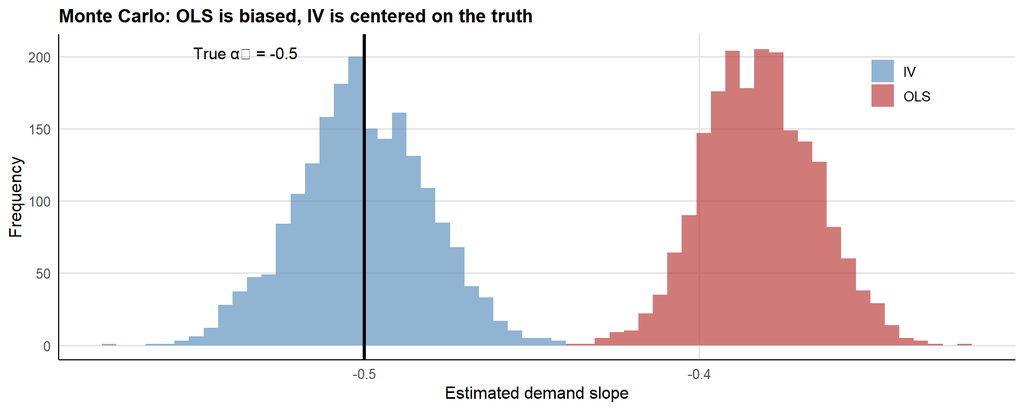

```r
n_sims <- 2000
n_obs  <- 500
ols_estimates <- numeric(n_sims)
iv_estimates  <- numeric(n_sims)

for (s in seq_len(n_sims)) {
  # Draw new shocks each simulation
  z_s   <- rnorm(n_obs, mean = 5, sd = 2)
  ud_s  <- rnorm(n_obs, mean = 0, sd = 1)
  us_s  <- rnorm(n_obs, mean = 0, sd = 1)

  # Equilibrium
  p_s <- ((gamma0 - alpha0) + delta * z_s + (us_s - ud_s)) / (alpha1 - gamma1)
  q_s <- alpha0 + alpha1 * p_s + ud_s

  # OLS
  ols_estimates[s] <- cov(p_s, q_s) / var(p_s)

  # IV (Wald ratio)
  iv_estimates[s] <- cov(z_s, q_s) / cov(z_s, p_s)
}

mc_df <- data.frame(
  estimate = c(ols_estimates, iv_estimates),
  method   = rep(c("OLS", "IV"), each = n_sims)
)

ggplot(mc_df, aes(x = estimate, fill = method)) +
  geom_histogram(alpha = 0.6, bins = 60, position = "identity") +
  geom_vline(xintercept = alpha1, linewidth = 1.2, linetype = "solid") +
  annotate("text", x = alpha1 - 0.02, y = Inf, label = paste("True α₁ =", alpha1),
           vjust = 2, hjust = 1, size = 4) +
  scale_fill_manual(values = c("OLS" = "firebrick", "IV" = "steelblue")) +
  labs(title = "Monte Carlo: OLS is biased, IV is centered on the truth",
       x = "Estimated demand slope", y = "Frequency", fill = NULL) +
  theme(legend.position = c(0.88, 0.85))
```

```r
cat("Mean OLS estimate:", mean(ols_estimates),
    "  (bias:", mean(ols_estimates) - alpha1, ")\n")
```

```
## Mean OLS estimate: -0.3819   (bias: 0.1181 )
```

```r
cat("Mean IV estimate: ", mean(iv_estimates),
    "  (bias:", mean(iv_estimates) - alpha1, ")\n\n")
```

```
## Mean IV estimate:  -0.5007   (bias: -0.0006764 )
```

```r
cat("SD of OLS:", sd(ols_estimates), "\n")
```

```
## SD of OLS: 0.01661
```

```r
cat("SD of IV: ", sd(iv_estimates), "\n")
```

```
## SD of IV:  0.01955
```

IV is **unbiased** (centered on truth) but has **larger variance** than OLS. This is the classic bias–variance tradeoff with IV.

# Part 3: Real data — returns to education

We apply our hand-coded IV estimator to a classic question: **what is the causal return to an additional year of schooling?**

## The problem

$$\log(\text{wage}_i) = \beta_0 + \beta_1 \, \text{educ}_i + u_i$$

OLS is biased because education is endogenous:

- **Omitted ability**: more able people get more education *and* earn more
- **Direction of bias**: OLS likely *overstates* the return to education

## The instrument: proximity to college

Card (1995) uses **proximity to a 4-year college** (`nearc4`) as an instrument:

- **Relevance**: Growing up near a college lowers the cost of attending $\Rightarrow$ increases education
- **Exogeneity**: Proximity to a college (plausibly) does not directly affect wages

```r
# Download Card (1995) data from the Rdatasets repository (wooldridge package)
url <- "https://raw.githubusercontent.com/vincentarelbundock/Rdatasets/master/csv/wooldridge/card.csv"
card <- read.csv(url)

# Key variables
#   lwage    : log hourly wage
#   educ     : years of education
#   nearc4   : =1 if grew up near a 4-year college
#   exper    : years of work experience
#   black    : =1 if Black
#   smsa     : =1 if lives in SMSA (metro area)
#   south    : =1 if lives in the South

cat("Observations:", nrow(card), "\n")
```

```
## Observations: 3010
```

```r
cat("Variables:   ", ncol(card), "\n\n")
```

```
## Variables:    35
```

```r
cat("Summary of key variables:\n")
```

```
## Summary of key variables:
```

```r
summary(card[, c("lwage", "educ", "nearc4", "exper")])
```

```
##      lwage           educ          nearc4          exper
##  Min.   :4.61   Min.   : 1.0   Min.   :0.000   Min.   : 0.00
##  1st Qu.:5.98   1st Qu.:12.0   1st Qu.:0.000   1st Qu.: 6.00
##  Median :6.29   Median :13.0   Median :1.000   Median : 8.00
##  Mean   :6.26   Mean   :13.3   Mean   :0.682   Mean   : 8.86
##  3rd Qu.:6.56   3rd Qu.:16.0   3rd Qu.:1.000   3rd Qu.:11.00
##  Max.   :7.79   Max.   :18.0   Max.   :1.000   Max.   :23.00
```

## OLS estimate

```r
ols_card <- lm(lwage ~ educ + exper + I(exper^2) + black + smsa + south,
               data = card)

cat("OLS return to education:", coef(ols_card)["educ"], "\n")
```

```
## OLS return to education: 0.07401
```

```r
cat("  (SE:", summary(ols_card)$coefficients["educ", "Std. Error"], ")\n")
```

```
##   (SE: 0.003505 )
```

## Check instrument validity

```r
# Relevance: does nearc4 predict education?
first_stage_card <- lm(educ ~ nearc4 + exper + I(exper^2) + black + smsa + south,
                       data = card)

cat("First-stage coefficient on nearc4:", coef(first_stage_card)["nearc4"], "\n")
```

```
## First-stage coefficient on nearc4: 0.3373
```

```r
cat("  (SE:", summary(first_stage_card)$coefficients["nearc4", "Std. Error"], ")\n")
```

```
##   (SE: 0.0825 )
```

```r
cat("  (t-stat:", summary(first_stage_card)$coefficients["nearc4", "t value"], ")\n\n")
```

```
##   (t-stat: 4.089 )
```

```r
# Partial F-statistic
# For a single instrument, F = t²
t_val <- summary(first_stage_card)$coefficients["nearc4", "t value"]
cat("First-stage F-statistic:", t_val^2, "\n")
```

```
## First-stage F-statistic: 16.72
```

```r
cat("Rule of thumb (Staiger-Stock): F > 10?", t_val^2 > 10, "\n")
```

```
## Rule of thumb (Staiger-Stock): F > 10? TRUE
```

## IV by hand (with controls)

With controls, we need to implement TSLS properly using the **Frisch-Waugh** logic: partial out the controls from everything, then apply IV to the residuals.

```r
iv_with_controls <- function(y, x_endog, z_instrument, controls) {
  # ------------------------------------------------------------------
  # TSLS with controls, implemented from scratch
  #
  # Strategy: Frisch-Waugh-Lovell
  #   1. Partial out controls from y, x, and z
  #   2. Run first stage on residualized x and z
  #   3. Run second stage on residualized y and x_hat
  #   4. Compute correct standard errors
  # ------------------------------------------------------------------
  n <- length(y)
  k <- ncol(controls) + 1  # total regressors (endog + controls)

  W <- cbind(1, controls)   # control matrix with intercept

  # Partial out controls (Frisch-Waugh)
  M_W    <- diag(n) - W %*% solve(crossprod(W), t(W))
  y_tild <- as.numeric(M_W %*% y)
  x_tild <- as.numeric(M_W %*% x_endog)
  z_tild <- as.numeric(M_W %*% z_instrument)

  # First stage (residualized)
  pi1     <- cov(z_tild, x_tild) / var(z_tild)
  x_hat_t <- pi1 * z_tild

  # First-stage F
  e1_tild <- x_tild - x_hat_t
  pi1_se  <- sqrt(sum(e1_tild^2) / (n - ncol(W) - 1) / sum(z_tild^2))
  F_stat  <- (pi1 / pi1_se)^2

  # Second stage (residualized)
  beta1 <- cov(x_hat_t, y_tild) / var(x_hat_t)
  # equivalently: cov(z_tild, y_tild) / cov(z_tild, x_tild)

  # Intercept: recover from full regression
  beta0 <- mean(y) - beta1 * mean(x_endog) -
    as.numeric(solve(crossprod(W), crossprod(W, y - beta1 * x_endog))[1])

  # Correct SE (use original x, not x_hat)
  u_hat  <- y_tild - beta1 * x_tild
  sigma2 <- sum(u_hat^2) / (n - k - 1)
  se1    <- sqrt(sigma2 / sum(x_hat_t^2))

  list(
    beta1         = beta1,
    se1           = se1,
    first_stage_F = F_stat,
    wald_check    = cov(z_tild, y_tild) / cov(z_tild, x_tild)
  )
}

# Set up controls matrix
controls <- as.matrix(card[, c("exper", "black", "smsa", "south")])
controls <- cbind(controls, card$exper^2)  # add exper²

iv_card <- iv_with_controls(
  y            = card$lwage,
  x_endog      = card$educ,
  z_instrument = card$nearc4,
  controls     = controls
)

cat("IV return to education:  ", iv_card$beta1, "\n")
```

```
## IV return to education:   0.1323
```

```r
cat("  (SE:", iv_card$se1, ")\n")
```

```
##   (SE: 0.04923 )
```

```r
cat("  First-stage F:         ", iv_card$first_stage_F, "\n\n")
```

```
##   First-stage F:          16.72
```

```r
cat("OLS return to education: ", coef(ols_card)["educ"], "\n")
```

```
## OLS return to education:  0.07401
```

```r
cat("  (SE:", summary(ols_card)$coefficients["educ", "Std. Error"], ")\n\n")
```

```
##   (SE: 0.003505 )
```

```r
cat("Wald check (should match):", iv_card$wald_check, "\n")
```

```
## Wald check (should match): 0.1323
```

## Comparison with `ivreg`

```r
if (!requireNamespace("ivreg", quietly = TRUE)) {
  install.packages("ivreg", repos = "https://cloud.r-project.org")
}
library(ivreg)

iv_pkg <- ivreg(lwage ~ educ + exper + I(exper^2) + black + smsa + south |
                  nearc4 + exper + I(exper^2) + black + smsa + south,
                data = card)

cat("Comparison of educ coefficient:\n")
```

```
## Comparison of educ coefficient:
```

```r
cat("  Hand-coded IV:", iv_card$beta1, "\n")
```

```
##   Hand-coded IV: 0.1323
```

```r
cat("  ivreg package:", coef(iv_pkg)["educ"], "\n\n")
```

```
##   ivreg package: 0.1323
```

```r
cat("Comparison of SE:\n")
```

```
## Comparison of SE:
```

```r
cat("  Hand-coded IV:", iv_card$se1, "\n")
```

```
##   Hand-coded IV: 0.04923
```

```r
cat("  ivreg package:", summary(iv_pkg)$coefficients["educ", "Std. Error"], "\n")
```

```
##   ivreg package: 0.04923
```

## Results summary

```r
results <- data.frame(
  Method = c("OLS", "IV (hand-coded)", "IV (ivreg)"),
  Estimate = c(
    coef(ols_card)["educ"],
    iv_card$beta1,
    coef(iv_pkg)["educ"]
  ),
  SE = c(
    summary(ols_card)$coefficients["educ", "Std. Error"],
    iv_card$se1,
    summary(iv_pkg)$coefficients["educ", "Std. Error"]
  )
)
results$CI_lower <- results$Estimate - 1.96 * results$SE
results$CI_upper <- results$Estimate + 1.96 * results$SE

knitr::kable(results, digits = 4, row.names = FALSE,
             caption = "Returns to education: OLS vs IV")
```

Returns to education: OLS vs IV

| Method | Estimate | SE | CI_lower | CI_upper |
| --- | --- | --- | --- | --- |
| OLS | 0.0740 | 0.0035 | 0.0671 | 0.0809 |
| IV (hand-coded) | 0.1323 | 0.0492 | 0.0358 | 0.2288 |
| IV (ivreg) | 0.1323 | 0.0492 | 0.0358 | 0.2288 |

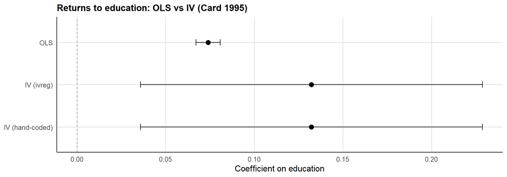

```r
ggplot(results, aes(x = Method, y = Estimate)) +
  geom_point(size = 3) +
  geom_errorbar(aes(ymin = CI_lower, ymax = CI_upper), width = 0.15) +
  geom_hline(yintercept = 0, linetype = "dashed", colour = "grey60") +
  labs(title = "Returns to education: OLS vs IV (Card 1995)",
       y = "Coefficient on education", x = NULL) +
  coord_flip()
```

## Interpretation

- **OLS** estimates a return of ~7.4% per year of schooling.
- **IV** estimates ~13.2% — the IV estimate is *larger* than OLS.
- This suggests that omitted-ability bias may actually push OLS *down*, not up. Card (1995) argues that the **local average treatment effect** (LATE) for compliers — people whose education is affected by college proximity — is larger than the average return.
- IV standard errors are larger: less precision is the price of consistency.

# Key takeaways

|  | OLS | IV / TSLS |
| --- | --- | --- |
| **Consistency** | Inconsistent if $\text{cov}(X, u) \neq 0$ | Consistent under relevance + exogeneity |
| **Efficiency** | More efficient (smaller SE) | Less efficient (larger SE) |
| **Bias** | Biased toward “hybrid” of structural parameters | Unbiased in large samples |
| **Formula** | $s_{XY} / s_X^2$ | $s_{ZY} / s_{ZX}$ |
| **What it estimates** | Something contaminated by endogeneity | LATE (for heterogeneous effects) |